# 5 rules for pain-free project management

October 10, 2022

## Rule 1

## Every project lives in its own folder.

[figure not shown]

*[Source](https://c0.wallpaperflare.com/preview/56/536/894/assorted-files.jpg)*

## Rule 2

## Not all subfolders are equal.

- Distinguish folder *types*, name them accordingly:
  - **Read-only**: data, metadata
  - **Human-generated**: code, paper, documentation
  - **Project-generated**: clean data, figures, models…
- This ensures you do not accidentally touch what you shouldn’t touch…
- …or that your project as it progresses clutters up your system.

## For example

```
PROJECT/
├── data/
│   ├── raw_data/
|   |   ├── metadata.json
|   |   └── raw_data.csv
│   └── clean_data/
|       └── data_cleaned.csv
├── results
│   ├── figures/
│   |   ├── chart.png
│   └── output/
│   |   └── statistics.csv
├── docs/
│   ├── manuscript.Rmd
│   └── journal.md
├── code/
│   ├── analyse_data.R
│   └── clean_data.R
└── README.md
```

## OK, stop.

## To hell with rules, let’s explain some things:

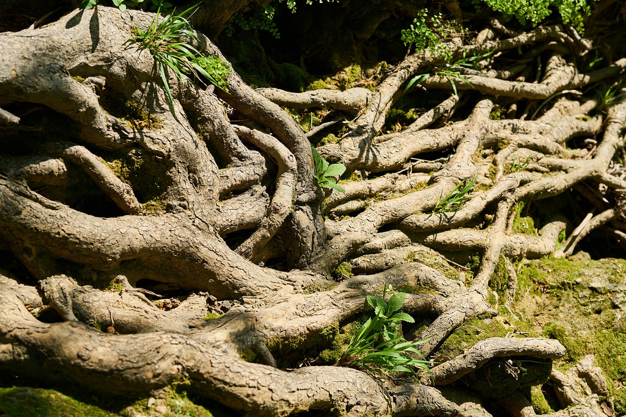

*[Source](https://www.maxpixel.net/Root-Big-Forest-Tree-Vein-Water-Strong-Old-4119112)*

## To hell with rules, let’s explain some things:

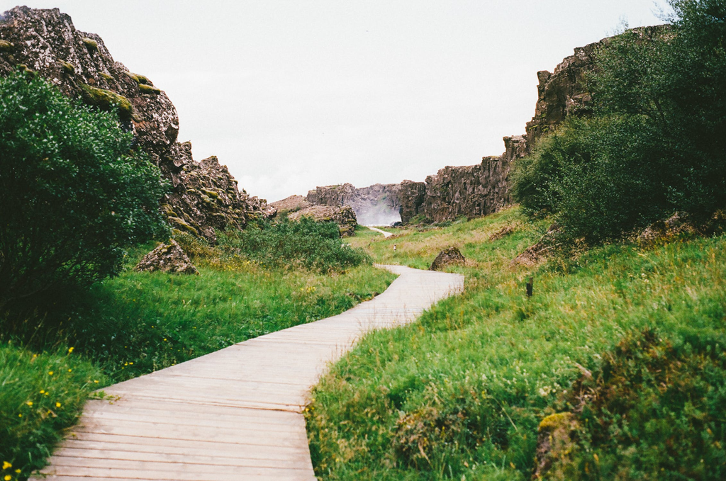

*[Source](https://www.pexels.com/photo/hiking-path-way-trail-4805/)*

## So that means…

```
PROJECT/
└── data/
    └── raw_data/
        ├── metadata.json
        └── raw_data.csv
```

The ROOT is `PROJECT/`

The PATH is, e.g., `PROJECT/data/raw_data/metadata.json`.

## Rule 3

## Everything is relative

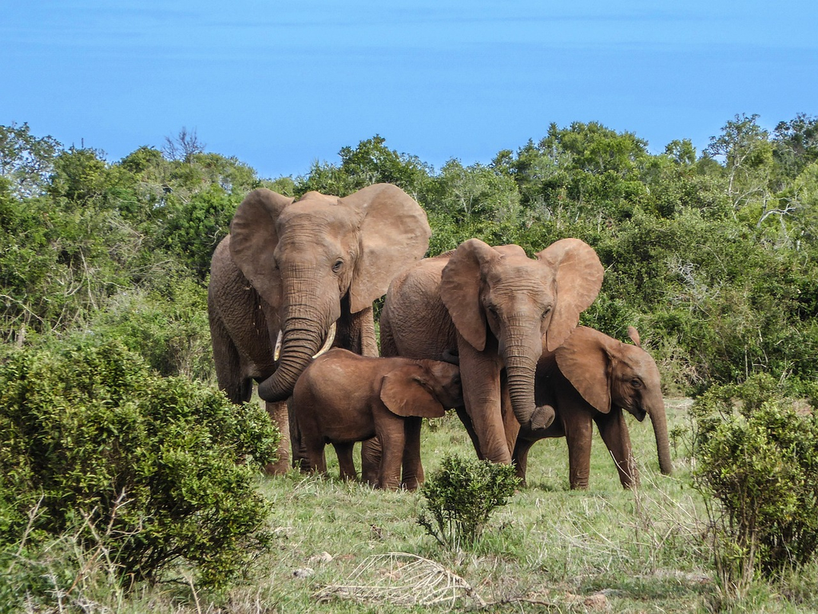

*[Source](https://pixabay.com/photos/elephant-family-elephant-safari-2776148/)*

## Everything is relative

```
PROJECT/
└── data/
    └── raw_data/
        ├── metadata.json
        └── raw_data.csv
```

A relative path: `PROJECT/data/raw_data/metadata.json`.

An absolute path: `/Users/bvreede/work/courses/2021/PROJECT/data/raw_data/metadata.json`

## Rule 4

## What’s in a name? Everything!

- What information do you need to have if this file was ever displaced?
- Use a schema, and be consistent. E.g.:

  ```
  maps_london_2018_openstreetmaps.png
  maps_paris_2020_google-earth.png
  maps_paris_2020_openstreetmaps.png
  maps_paris_2022_openstreetmaps.png
  ```

- Sort the elements in your schema logically. E.g. `2020-05-30` instead of `30-05-2020`.
- No spaces, and limit special characters… but do use CamelCase or connecting_underscores.
- Document your naming practice, ESPECIALLY when using abbreviations.

## Rule 5

## There is no such thing as TMI

[figure not shown]

## Make a README file… or more

### Where?

- In the `root/`
- Whenever necessary, in subfolders

### What information do you want to see in a README?

- What is this project about?
- What information do you need to understand this data?
- Any abbreviations or coding, inside the files or in their names
- Sources of data, links to other projects -…

## Let’s do this together

## To start: basic organization

- open a single folder for today’s work
- make subfolders:
  - `data/` (this will be read-only)
  - `code/` (we will work in this!)
  - `documents/` (and in this one)
  - `results/` (this will be worked in by our project!)
- download this zip file: **tinyurl.com/urbanism-zipped**
- place the data and documents in the right location in your folder structure

## Moving on to the next phase…

- Let’s meet R and Rstudio!